# Открытие депозита

Смирнов Евгений, 274 группа

April 30, 2016

Имеются результаты обзвона 4119 клиентов португальского банка, которым предлагалось завести депозит. Известны социально-демографические характеристики клиентов, история предыдущих коммуникаций, социально-экономические показатели на момент совершения звонка. Какие признаки определяют готовность клиента открыть депозит по результатам обзвона?

```r
data <- read.csv("deposit.csv")
n1 = length(data$age)
```

Посмотрим на график data$duration:

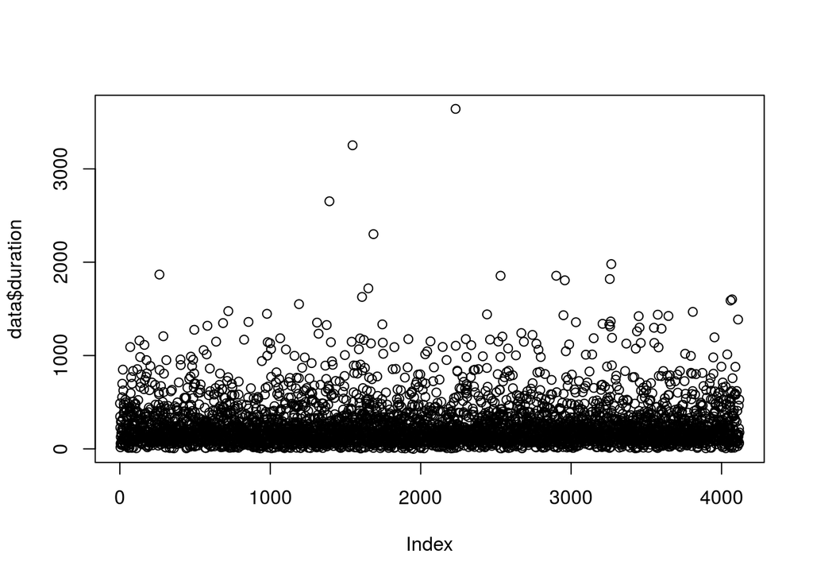

```r
plot(data$duration)
```

Удалим выбросы:

```r
data <- data[data$duration < 1500,]
```

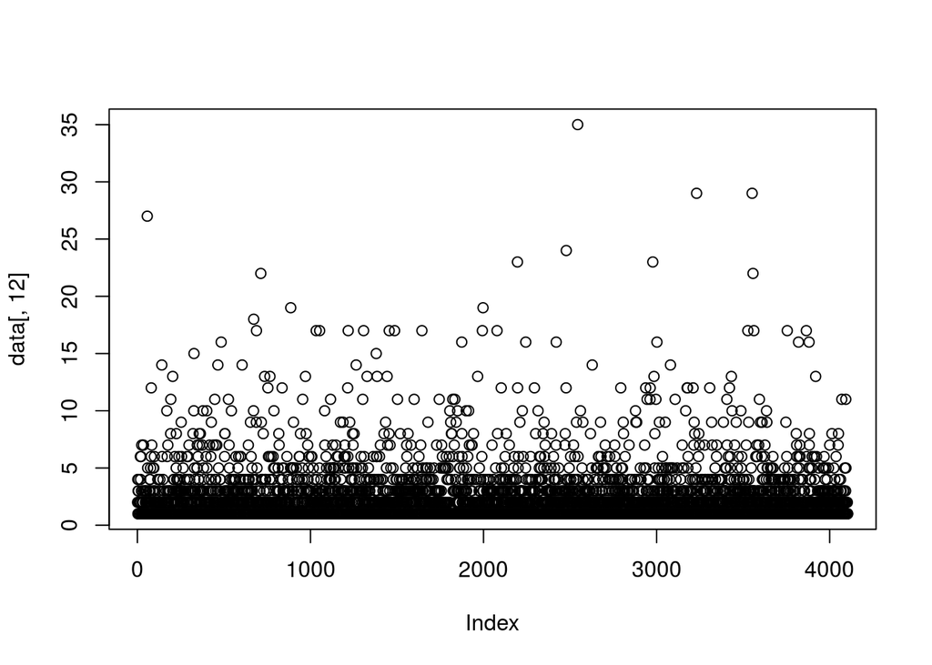

```r
plot(data[,12])
```

```r
data <- data[data[,12] < 25,]
```

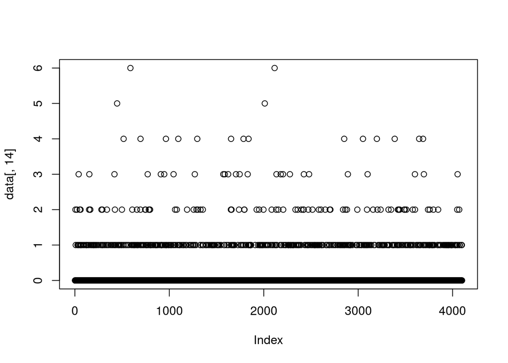

```r
plot(data[,14])
```

```r
data <- data[data[,14] < 5,]
```

Посмотрим на распределения непрерывных признаков в классах:

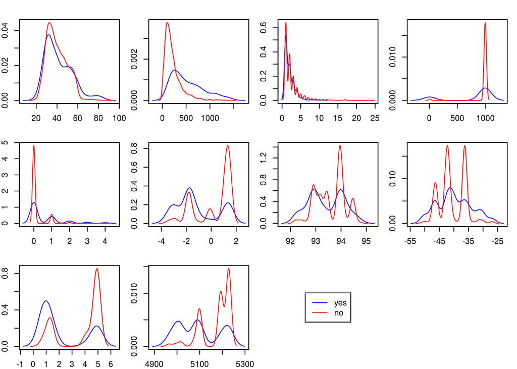

```r
par(mfrow=c(3,4), mar=c(2, 2, 2, 1))
for (i in c(1,11:14,16:20)){
  d1 <- density(data[data$y == "yes",i])
  d2 <- density(data[data$y == "no",i])
  plot(d1, col="blue", xlim=c(min(d1$x, d2$x), max(d1$x, d2$x)), ylim=c(min(d1$y, d2$y), max(d1$y, d2$y)), xlab=colnames(data)[i], main="")
  lines(d2, col="red")
}

plot(1, type = "n", axes=FALSE, xlab="", ylab="")
legend("center", c("yes", "no"), lty=c(1,1), col=c("blue", "red"))
```

Линейной разделимости по отдельным признакам нет.

Посмотрим на таблицы сопряжённости по категориальным признакам:

```r
for (i in c(2:10,15)) {
  print(colnames(data)[i])
  print(ftable(data[,i], data$y))
}
```

```
## [1] "job"
##                 no yes
##
## admin.         875 128
## blue-collar    822  58
## entrepreneur   139   7
## housemaid       99  10
## management     294  29
## retired        127  38
## self-employed  146  13
## services       355  35
## student         63  19
## technician     611  79
## unemployed      91  19
## unknown         35   4
## [1] "marital"
##             no  yes
##
## divorced   402   39
## married   2252  246
## single     993  153
## unknown     10    1
## [1] "education"
##                        no  yes
##
## basic.4y              390   38
## basic.6y              211   15
## basic.9y              530   43
## high.school           820   94
## illiterate              1    0
## professional.course   468   61
## university.degree    1096  163
## unknown               141   25
## [1] "default"
##            no  yes
##
## no       2903  390
## unknown   753   49
## yes         1    0
## [1] "housing"
```

[output cut: 28 more lines]

```
## sep    37   25
## [1] "day_of_week"
##       no yes
##
## fri  682  80
## mon  757  94
## thu  759  95
## tue  748  88
## wed  711  82
## [1] "poutcome"
##                no  yes
##
## failure       386   67
## nonexistent  3222  285
## success        49   87
```

```r
data <- data[data$default != "yes",]
data <- data[data$education != "illiterate",]
n2 = length(data$age)
out <- 1-n2/n1
```

Удалено 0.6069434% данных.

```r
m0 <- glm(y~1, family=binomial(), data=data)
add1(m0, scope = as.formula(paste("~", paste(head(colnames(data), -1), collapse= " + "))), test="LRT")
```

```
## Single term additions
##
## Model:
## y ~ 1
##                Df Deviance    AIC    LRT  Pr(>Chi)
## <none>              2789.5 2791.5
## age             1   2778.8 2782.8  10.72 0.0010604 **
## job            11   2721.2 2745.2  68.36 2.496e-10 ***
## marital         3   2778.1 2786.1  11.48 0.0094142 **
## education       6   2767.0 2781.0  22.56 0.0009577 ***
## default         1   2764.6 2768.6  24.97 5.830e-07 ***
## housing         2   2789.0 2795.0   0.56 0.7575929
## loan            2   2788.6 2794.6   0.90 0.6374710
## contact         1   2702.8 2706.8  86.76 < 2.2e-16 ***
## month           9   2582.7 2602.7 206.87 < 2.2e-16 ***
## day_of_week     4   2789.1 2799.1   0.42 0.9809833
## duration        1   2258.1 2262.1 531.41 < 2.2e-16 ***
## campaign        1   2758.8 2762.8  30.68 3.036e-08 ***
## pdays           1   2539.4 2543.4 250.11 < 2.2e-16 ***
## previous        1   2612.9 2616.9 176.62 < 2.2e-16 ***
## poutcome        2   2533.8 2539.8 255.68 < 2.2e-16 ***
## emp.var.rate    1   2483.8 2487.8 305.71 < 2.2e-16 ***
## cons.price.idx  1   2746.4 2750.4  43.17 5.023e-11 ***
## cons.conf.idx   1   2775.8 2779.8  13.74 0.0002097 ***
## euribor3m       1   2449.5 2453.5 340.05 < 2.2e-16 ***
## nr.employed     1   2366.1 2370.1 423.45 < 2.2e-16 ***
## ---
## Signif. codes:  0 '***' 0.001 '**' 0.01 '*' 0.05 '.' 0.1 ' ' 1
```

# Модель 1

Многомерная модель со всеми предикторами, значимыми на уровне 0.25(удалили housing, loan, day_of_week):

```r
m1 <- glm(y ~ age + job + marital + default + education + contact + month + duration + campaign + pdays + previous + poutcome + emp.var.rate + cons.price.idx + cons.conf.idx + euribor3m + nr.employed, family=binomial(), data=data)
summary(m1)
```

```
##
## Call:
## glm(formula = y ~ age + job + marital + default + education +
##     contact + month + duration + campaign + pdays + previous +
##     poutcome + emp.var.rate + cons.price.idx + cons.conf.idx +
##     euribor3m + nr.employed, family = binomial(), data = data)
##
## Deviance Residuals:
##     Min       1Q   Median       3Q      Max
## -3.6206  -0.2679  -0.1607  -0.1047   2.8671
##
## Coefficients:
##                                Estimate Std. Error z value Pr(>|z|)
## (Intercept)                  -1.736e+02  1.236e+02  -1.405 0.160109
## age                           6.709e-03  8.337e-03   0.805 0.420930
## jobblue-collar               -1.795e-01  2.769e-01  -0.648 0.516822
## jobentrepreneur              -6.340e-01  4.922e-01  -1.288 0.197707
## jobhousemaid                  2.560e-01  4.541e-01   0.564 0.572872
## jobmanagement                -3.495e-01  2.944e-01  -1.187 0.235272
## jobretired                   -1.349e-01  3.517e-01  -0.384 0.701209
## jobself-employed             -8.091e-01  4.262e-01  -1.898 0.057644 .
## jobservices                   1.616e-01  2.847e-01   0.568 0.570209
## jobstudent                   -5.432e-02  4.030e-01  -0.135 0.892793
## jobtechnician                 1.894e-01  2.299e-01   0.824 0.409990
## jobunemployed                 4.610e-01  3.912e-01   1.178 0.238698
## jobunknown                   -4.962e-01  7.584e-01  -0.654 0.512938
## maritalmarried                2.571e-01  2.512e-01   1.023 0.306105
## maritalsingle                 2.860e-01  2.858e-01   1.001 0.317007
## maritalunknown                2.500e-01  1.148e+00   0.218 0.827564
## defaultunknown                1.407e-01  2.145e-01   0.656 0.511807
## educationbasic.6y             2.667e-01  4.168e-01   0.640 0.522237
## educationbasic.9y             1.281e-01  3.290e-01   0.389 0.697098
## educationhigh.school          1.554e-01  3.121e-01   0.498 0.618651
## educationprofessional.course  1.532e-01  3.401e-01   0.450 0.652352
## educationuniversity.degree    3.359e-01  3.137e-01   1.071 0.284287
## educationunknown              2.189e-01  3.951e-01   0.554 0.579638
## contacttelephone             -9.653e-01  2.837e-01  -3.402 0.000669 ***
## monthaug                      6.830e-01  4.210e-01   1.622 0.104715
## monthdec                      1.032e+00  6.901e-01   1.496 0.134708
## monthjul                      1.808e-01  3.684e-01   0.491 0.623532
```

[output cut: 12 more lines]

```
## emp.var.rate                 -1.131e+00  4.693e-01  -2.410 0.015961 *
## cons.price.idx                1.652e+00  8.164e-01   2.024 0.042980 *
## cons.conf.idx                 5.948e-02  2.662e-02   2.235 0.025448 *
## euribor3m                    -2.627e-02  4.222e-01  -0.062 0.950375
## nr.employed                   3.149e-03  1.000e-02   0.315 0.752844
## ---
## Signif. codes:  0 '***' 0.001 '**' 0.01 '*' 0.05 '.' 0.1 ' ' 1
##
## (Dispersion parameter for binomial family taken to be 1)
##
##     Null deviance: 2789.5  on 4093  degrees of freedom
## Residual deviance: 1526.5  on 4050  degrees of freedom
## AIC: 1614.5
##
## Number of Fisher Scoring iterations: 7
```

Критерий отношения правдоподобия считает такую модель существенно лучшей константы:

```r
lrtest(m0, m1)
```

```
## Likelihood ratio test
##
## Model 1: y ~ 1
## Model 2: y ~ age + job + marital + default + education + contact + month +
##     duration + campaign + pdays + previous + poutcome + emp.var.rate +
##     cons.price.idx + cons.conf.idx + euribor3m + nr.employed
##   #Df   LogLik Df Chisq Pr(>Chisq)
## 1   1 -1394.76
## 2  44  -763.26 43  1263  < 2.2e-16 ***
## ---
## Signif. codes:  0 '***' 0.001 '**' 0.01 '*' 0.05 '.' 0.1 ' ' 1
```

Признаки age, marital, nr.employed, euribor3m, previous, pdays, education, default не являются значимыми - выкинем их.

```r
m2 <- glm(y ~   job  + contact + month + duration + campaign + poutcome + emp.var.rate + cons.price.idx + cons.conf.idx , family=binomial(), data=data)
summary(m2)
```

```
##
## Call:
## glm(formula = y ~ job + contact + month + duration + campaign +
##     poutcome + emp.var.rate + cons.price.idx + cons.conf.idx,
##     family = binomial(), data = data)
##
## Deviance Residuals:
##     Min       1Q   Median       3Q      Max
## -3.6126  -0.2695  -0.1621  -0.1069   2.8263
##
## Coefficients:
##                       Estimate Std. Error z value Pr(>|z|)
## (Intercept)         -1.345e+02  1.657e+01  -8.118 4.74e-16 ***
## jobblue-collar      -2.671e-01  2.222e-01  -1.202 0.229246
## jobentrepreneur     -6.305e-01  4.848e-01  -1.300 0.193440
## jobhousemaid         1.954e-01  4.268e-01   0.458 0.647064
## jobmanagement       -2.719e-01  2.852e-01  -0.953 0.340485
## jobretired          -9.671e-02  2.836e-01  -0.341 0.733080
## jobself-employed    -8.194e-01  4.228e-01  -1.938 0.052632 .
## jobservices          7.413e-02  2.671e-01   0.278 0.781383
## jobstudent          -1.770e-01  3.641e-01  -0.486 0.626881
## jobtechnician        1.473e-01  2.083e-01   0.707 0.479381
## jobunemployed        4.052e-01  3.823e-01   1.060 0.289223
## jobunknown          -4.615e-01  7.438e-01  -0.620 0.535002
## contacttelephone    -9.329e-01  2.562e-01  -3.641 0.000271 ***
## monthaug             6.630e-01  3.729e-01   1.778 0.075401 .
## monthdec             9.780e-01  6.418e-01   1.524 0.127588
## monthjul             1.730e-01  3.565e-01   0.485 0.627404
## monthjun             6.028e-01  3.211e-01   1.877 0.060503 .
## monthmar             2.611e+00  4.353e-01   5.997 2.00e-09 ***
## monthmay            -2.999e-01  2.848e-01  -1.053 0.292344
## monthnov            -2.832e-01  3.491e-01  -0.811 0.417150
## monthoct             4.515e-01  4.365e-01   1.034 0.300996
## monthsep             3.327e-01  4.436e-01   0.750 0.453260
## duration             5.834e-03  2.801e-04  20.829  < 2e-16 ***
## campaign            -1.014e-01  4.661e-02  -2.176 0.029556 *
## poutcomenonexistent  3.671e-01  2.032e-01   1.806 0.070849 .
## poutcomesuccess      1.782e+00  2.768e-01   6.439 1.20e-10 ***
## emp.var.rate        -9.639e-01  7.962e-02 -12.106  < 2e-16 ***
## cons.price.idx       1.412e+00  1.791e-01   7.886 3.12e-15 ***
## cons.conf.idx        5.679e-02  1.796e-02   3.162 0.001570 **
## ---
## Signif. codes:  0 '***' 0.001 '**' 0.01 '*' 0.05 '.' 0.1 ' ' 1
##
## (Dispersion parameter for binomial family taken to be 1)
##
##     Null deviance: 2789.5  on 4093  degrees of freedom
## Residual deviance: 1532.7  on 4065  degrees of freedom
## AIC: 1590.7
##
## Number of Fisher Scoring iterations: 7
```

Попробуем выкинть job, как незначимый признак.

```r
m3 <- glm(y ~ contact + month + duration + campaign + poutcome + emp.var.rate + cons.price.idx + cons.conf.idx , family=binomial(), data=data)
summary(m3)
```

```
##
## Call:
## glm(formula = y ~ contact + month + duration + campaign + poutcome +
##     emp.var.rate + cons.price.idx + cons.conf.idx, family = binomial(),
##     data = data)
##
## Deviance Residuals:
##     Min       1Q   Median       3Q      Max
## -3.6111  -0.2687  -0.1629  -0.1107   2.8062
##
## Coefficients:
##                       Estimate Std. Error z value Pr(>|z|)
## (Intercept)         -1.347e+02  1.624e+01  -8.293  < 2e-16 ***
## contacttelephone    -9.148e-01  2.528e-01  -3.618 0.000297 ***
## monthaug             7.040e-01  3.659e-01   1.924 0.054380 .
## monthdec             9.765e-01  6.189e-01   1.578 0.114634
## monthjul             1.991e-01  3.508e-01   0.568 0.570368
## monthjun             5.892e-01  3.159e-01   1.865 0.062141 .
## monthmar             2.584e+00  4.302e-01   6.006 1.90e-09 ***
## monthmay            -3.413e-01  2.802e-01  -1.218 0.223197
## monthnov            -3.108e-01  3.444e-01  -0.903 0.366759
## monthoct             4.901e-01  4.296e-01   1.141 0.253936
## monthsep             3.795e-01  4.407e-01   0.861 0.389192
## duration             5.772e-03  2.768e-04  20.852  < 2e-16 ***
## campaign            -1.038e-01  4.663e-02  -2.226 0.026015 *
## poutcomenonexistent  3.922e-01  2.006e-01   1.955 0.050539 .
## poutcomesuccess      1.821e+00  2.726e-01   6.679 2.41e-11 ***
## emp.var.rate        -9.667e-01  7.707e-02 -12.543  < 2e-16 ***
## cons.price.idx       1.414e+00  1.757e-01   8.046 8.53e-16 ***
## cons.conf.idx        5.588e-02  1.776e-02   3.147 0.001649 **
## ---
## Signif. codes:  0 '***' 0.001 '**' 0.01 '*' 0.05 '.' 0.1 ' ' 1
##
## (Dispersion parameter for binomial family taken to be 1)
##
##     Null deviance: 2789.5  on 4093  degrees of freedom
## Residual deviance: 1545.1  on 4076  degrees of freedom
## AIC: 1581.1
##
## Number of Fisher Scoring iterations: 7
```

```r
lrtest(m3,m2)
```

```
## Likelihood ratio test
##
## Model 1: y ~ contact + month + duration + campaign + poutcome + emp.var.rate +
##     cons.price.idx + cons.conf.idx
## Model 2: y ~ job + contact + month + duration + campaign + poutcome +
##     emp.var.rate + cons.price.idx + cons.conf.idx
##   #Df  LogLik Df  Chisq Pr(>Chisq)
## 1  18 -772.54
## 2  29 -766.36 11 12.366     0.3368
```

Стало не хуже. Будем дальше работать с моделью 3.

Модель 3 не хуже 1. В модели значимы duration, campaign, emp.var.rate, cons.price.idx, cons.conf.idx, poutcome = success, month = mar, contact = telephone.

```r
lrtest(m3, m1)
```

```
## Likelihood ratio test
##
## Model 1: y ~ contact + month + duration + campaign + poutcome + emp.var.rate +
##     cons.price.idx + cons.conf.idx
## Model 2: y ~ age + job + marital + default + education + contact + month +
##     duration + campaign + pdays + previous + poutcome + emp.var.rate +
##     cons.price.idx + cons.conf.idx + euribor3m + nr.employed
##   #Df  LogLik Df  Chisq Pr(>Chisq)
## 1  18 -772.54
## 2  44 -763.26 26 18.578     0.8538
```

Попробуем возращать признаки по одному:

```r
add1(m3, ~ . + job + housing + loan + day_of_week + age + marital + nr.employed + euribor3m + previous + pdays + education + default,  test="LRT")
```

```
## Single term additions
##
## Model:
## y ~ contact + month + duration + campaign + poutcome + emp.var.rate +
##     cons.price.idx + cons.conf.idx
##             Df Deviance    AIC     LRT Pr(>Chi)
## <none>           1545.1 1581.1
## job         11   1532.7 1590.7 12.3656   0.3368
## housing      2   1544.0 1584.0  1.1372   0.5663
## loan         2   1544.2 1584.2  0.9093   0.6347
## day_of_week  4   1543.3 1587.3  1.7658   0.7787
## age          1   1545.0 1583.0  0.0469   0.8285
## marital      3   1544.0 1586.0  1.0963   0.7780
## nr.employed  1   1545.0 1583.0  0.0425   0.8366
## euribor3m    1   1545.0 1583.0  0.0418   0.8381
## previous     1   1543.1 1581.1  1.9716   0.1603
## pdays        1   1543.9 1581.9  1.1545   0.2826
## education    6   1543.5 1591.5  1.5848   0.9537
## default      1   1544.8 1582.8  0.3049   0.5808
```

Существенно лучше не стало.

Проверим линейность логита по непрерывным признакам. Сглаженные диаграммы рассеяния:

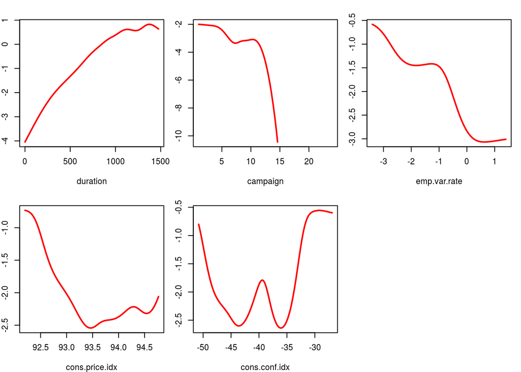

```r
par(mfrow=c(2,3), mar=c(4, 2, 2, 1))
lw  <- ksmooth(data$duration, 1 * (data$y == "yes"), kernel = "normal", bandwidth=sd(data$duration))
lsm <- log(lw$y / (1-lw$y))
plot(lw$x, lsm, type="l", xlab="duration", ylab ="Log-odds",col="red", lwd=2)

lw  <- ksmooth(data$campaign, 1 * (data$y == "yes"), kernel = "normal", bandwidth=sd(data$campaign))
lsm <- log(lw$y / (1-lw$y))
plot(lw$x, lsm, type="l", xlab="campaign", ylab ="Log-odds",col="red", lwd=2)

lw  <- ksmooth(data$emp.var.rate, 1 * (data$y == "yes"), kernel = "normal", bandwidth=sd(data$emp.var.rate))
lsm <- log(lw$y / (1-lw$y))
plot(lw$x, lsm, type="l", xlab="emp.var.rate", ylab ="Log-odds",col="red", lwd=2)

lw  <- ksmooth(data$cons.price.idx, 1 * (data$y == "yes"), kernel = "normal", bandwidth=sd(data$cons.price.idx))
lsm <- log(lw$y / (1-lw$y))
plot(lw$x, lsm, type="l", xlab="cons.price.idx", ylab ="Log-odds",col="red", lwd=2)

lw  <- ksmooth(data$cons.conf.idx, 1 * (data$y == "yes"), kernel = "normal", bandwidth=sd(data$cons.conf.idx))
lsm <- log(lw$y / (1-lw$y))
plot(lw$x, lsm, type="l", xlab="cons.conf.idx", ylab ="Log-odds",col="red", lwd=2)
```

По всем признакам кроме duration логит существенно нелинеен. Попробуем подобрать дробные полиномы для непрерывных признаков:

```r
mfp(y ~ fp(duration) + fp(campaign) + fp(emp.var.rate) + fp(cons.price.idx) + fp(cons.conf.idx) + poutcome + month + contact, family = binomial(), data=data)
```

```
## Call:
## mfp(formula = y ~ fp(duration) + fp(campaign) + fp(emp.var.rate) +
##     fp(cons.price.idx) + fp(cons.conf.idx) + poutcome + month +
##     contact, data = data, family = binomial())
##
##
## Deviance table:
##           Resid. Dev
## Null model    2789.526
## Linear model  1545.088
## Final model   1499.277
##
## Fractional polynomials:
##                     df.initial select alpha df.final power1 power2
## duration                     4      1  0.05        4    0.5      3
## emp.var.rate                 4      1  0.05        1      1      .
## cons.price.idx               4      1  0.05        1      1      .
## monthaug                     1      1  0.05        1      1      .
## monthdec                     1      1  0.05        1      1      .
## monthjul                     1      1  0.05        1      1      .
## monthjun                     1      1  0.05        1      1      .
## monthmar                     1      1  0.05        1      1      .
## monthmay                     1      1  0.05        1      1      .
## monthnov                     1      1  0.05        1      1      .
## monthoct                     1      1  0.05        1      1      .
## monthsep                     1      1  0.05        1      1      .
## poutcomenonexistent          1      1  0.05        1      1      .
## poutcomesuccess              1      1  0.05        1      1      .
## contacttelephone             1      1  0.05        1      1      .
## cons.conf.idx                4      1  0.05        1      1      .
## campaign                     4      1  0.05        1      1      .
##
##
## Transformations of covariates:
##                                                          formula
## duration       I(((duration+1)/100)^0.5)+I(((duration+1)/100)^3)
## campaign                                           I(campaign^1)
## emp.var.rate                        I(((emp.var.rate+3.5)/10)^1)
## cons.price.idx                         I((cons.price.idx/100)^1)
## cons.conf.idx                     I(((cons.conf.idx+50.9)/10)^1)
```

[output cut: 11 more lines]

```
##            -9.847e+00              1.367e+02              8.007e-01
##            monthdec.1             monthjul.1             monthjun.1
##             1.028e+00              3.429e-01              6.776e-01
##            monthmar.1             monthmay.1             monthnov.1
##             2.903e+00             -3.194e-01             -1.622e-01
##            monthoct.1             monthsep.1  poutcomenonexistent.1
##             6.922e-01              4.170e-01              3.938e-01
##     poutcomesuccess.1     contacttelephone.1        cons.conf.idx.1
##             1.895e+00             -8.101e-01              6.383e-01
##            campaign.1
##            -8.916e-02
##
## Degrees of Freedom: 4093 Total (i.e. Null);  4075 Residual
## Null Deviance:       2790
## Residual Deviance: 1499  AIC: 1537
```

```r
m4 <- glm(y ~ I((duration)^0.5+(duration)^3) + campaign + emp.var.rate + cons.price.idx + cons.conf.idx + poutcome + month + contact, family=binomial(), data=data)
summary(m4)
```

```
##
## Call:
## glm(formula = y ~ I((duration)^0.5 + (duration)^3) + campaign +
##     emp.var.rate + cons.price.idx + cons.conf.idx + poutcome +
##     month + contact, family = binomial(), data = data)
##
## Deviance Residuals:
##     Min       1Q   Median       3Q      Max
## -4.0573  -0.3191  -0.2547  -0.1889   2.9034
##
## Coefficients:
##                                    Estimate Std. Error z value Pr(>|z|)
## (Intercept)                      -1.327e+02  1.511e+01  -8.781  < 2e-16
## I((duration)^0.5 + (duration)^3)  3.241e-09  2.212e-10  14.656  < 2e-16
## campaign                         -1.011e-01  4.214e-02  -2.398  0.01646
## emp.var.rate                     -8.474e-01  6.903e-02 -12.275  < 2e-16
## cons.price.idx                    1.412e+00  1.637e-01   8.620  < 2e-16
## cons.conf.idx                     5.214e-02  1.637e-02   3.186  0.00144
## poutcomenonexistent               3.850e-01  1.864e-01   2.065  0.03888
## poutcomesuccess                   1.761e+00  2.571e-01   6.851 7.32e-12
## monthaug                          3.194e-01  3.339e-01   0.957  0.33882
## monthdec                          9.146e-01  5.588e-01   1.637  0.10167
## monthjul                         -1.774e-02  3.231e-01  -0.055  0.95622
## monthjun                          3.847e-01  2.880e-01   1.336  0.18161
## monthmar                          2.051e+00  3.968e-01   5.168 2.36e-07
## monthmay                         -3.557e-01  2.547e-01  -1.396  0.16262
## monthnov                         -5.150e-01  3.152e-01  -1.634  0.10234
## monthoct                          1.018e-01  3.892e-01   0.262  0.79370
## monthsep                          1.134e-01  4.039e-01   0.281  0.77893
## contacttelephone                 -1.057e+00  2.361e-01  -4.478 7.53e-06
##
## (Intercept)                      ***
## I((duration)^0.5 + (duration)^3) ***
## campaign                         *
## emp.var.rate                     ***
## cons.price.idx                   ***
## cons.conf.idx                    **
## poutcomenonexistent              *
## poutcomesuccess                  ***
## monthaug
## monthdec
## monthjul
## monthjun
## monthmar                         ***
## monthmay
## monthnov
## monthoct
## monthsep
## contacttelephone                 ***
## ---
## Signif. codes:  0 '***' 0.001 '**' 0.01 '*' 0.05 '.' 0.1 ' ' 1
##
## (Dispersion parameter for binomial family taken to be 1)
##
##     Null deviance: 2789.5  on 4093  degrees of freedom
## Residual deviance: 1818.4  on 4076  degrees of freedom
## AIC: 1854.4
##
## Number of Fisher Scoring iterations: 6
```

У модели с преобразованными признаками большая аномальность, то есть, она хуже объясняет выборку. Посмотрим на сглаженную диаграмму рассеяния для преобразованного признака:

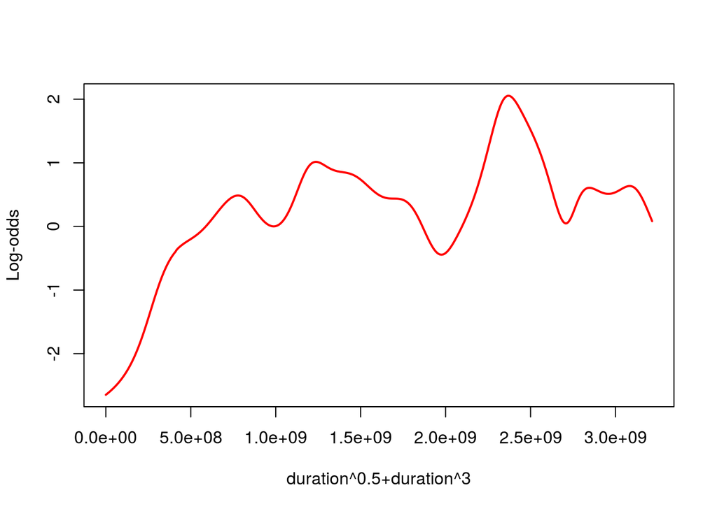

```r
lw  <- ksmooth( (data$duration)^0.5+(data$duration)^3, 1 * (data$y == "yes"), kernel = "normal", bandwidth=sd((data$duration)^0.5+(data$duration)^3) )
lsm <- log(lw$y / (1-lw$y))
plot(lw$x, lsm, type="l", xlab="duration^0.5+duration^3", ylab ="Log-odds",col="red", lwd=2)
```

Попробуем добавлять в линейную модель попарные взаимодействия:

```r
add1(m3, scope= ~ .^2, test="LRT")
```

```
## Single term additions
##
## Model:
## y ~ contact + month + duration + campaign + poutcome + emp.var.rate +
##     cons.price.idx + cons.conf.idx
##                              Df Deviance    AIC    LRT  Pr(>Chi)
## <none>                            1545.1 1581.1
## contact:month                 9   1537.8 1591.8  7.279 0.6080849
## contact:duration              1   1543.1 1581.1  1.979 0.1594848
## contact:campaign              1   1543.7 1581.7  1.397 0.2372809
## contact:poutcome              2   1541.6 1581.6  3.499 0.1738760
## contact:emp.var.rate          1   1545.0 1583.0  0.092 0.7615012
## contact:cons.price.idx        1   1544.9 1582.9  0.207 0.6489190
## contact:cons.conf.idx         1   1544.6 1582.6  0.462 0.4965906
## month:duration                9   1511.6 1565.6 33.492 0.0001096 ***
## month:campaign                9   1529.7 1583.7 15.440 0.0795426 .
## month:poutcome               18   1512.7 1584.7 32.384 0.0197927 *
## month:emp.var.rate            7   1529.5 1579.5 15.642 0.0285958 *
## month:cons.price.idx          9   1533.3 1587.3 11.734 0.2287495
## month:cons.conf.idx           9   1532.5 1586.5 12.610 0.1810516
## duration:campaign             1   1543.9 1581.9  1.171 0.2792414
## duration:poutcome             2   1543.7 1583.7  1.381 0.5014317
## duration:emp.var.rate         1   1532.6 1570.6 12.456 0.0004166 ***
## duration:cons.price.idx       1   1535.4 1573.4  9.682 0.0018604 **
## duration:cons.conf.idx        1   1542.7 1580.7  2.359 0.1245288
## campaign:poutcome             2   1543.2 1583.2  1.857 0.3950485
## campaign:emp.var.rate         1   1544.9 1582.9  0.157 0.6916790
## campaign:cons.price.idx       1   1543.1 1581.1  1.944 0.1632314
## campaign:cons.conf.idx        1   1544.3 1582.3  0.795 0.3726521
## poutcome:emp.var.rate         2   1544.6 1584.6  0.525 0.7691695
## poutcome:cons.price.idx       2   1542.0 1582.0  3.129 0.2092212
## poutcome:cons.conf.idx        2   1544.0 1584.0  1.138 0.5660830
## emp.var.rate:cons.price.idx   1   1545.0 1583.0  0.105 0.7462185
## emp.var.rate:cons.conf.idx    1   1545.0 1583.0  0.068 0.7940464
## cons.price.idx:cons.conf.idx  1   1545.0 1583.0  0.085 0.7709881
## ---
## Signif. codes:  0 '***' 0.001 '**' 0.01 '*' 0.05 '.' 0.1 ' ' 1
```

Добавим наиболее значимые взаимодействия:

```r
m5 <- glm(y ~  duration + campaign + emp.var.rate + cons.price.idx + cons.conf.idx + poutcome + month + contact  + month:duration + month:poutcome  + duration:emp.var.rate + duration:cons.price.idx + month:emp.var.rate, family=binomial(), data=data)
summary(m5)
```

```
##
## Call:
## glm(formula = y ~ duration + campaign + emp.var.rate + cons.price.idx +
##     cons.conf.idx + poutcome + month + contact + month:duration +
##     month:poutcome + duration:emp.var.rate + duration:cons.price.idx +
##     month:emp.var.rate, family = binomial(), data = data)
##
## Deviance Residuals:
##     Min       1Q   Median       3Q      Max
## -3.5805  -0.2504  -0.1391  -0.0844   2.9808
##
## Coefficients: (2 not defined because of singularities)
##                                Estimate Std. Error z value Pr(>|z|)
## (Intercept)                  -9.148e+01  3.483e+01  -2.627 0.008625 **
## duration                     -1.563e-01  9.673e-02  -1.616 0.106196
## campaign                     -1.169e-01  4.943e-02  -2.364 0.018071 *
## emp.var.rate                 -2.010e-01  3.644e-01  -0.551 0.581320
## cons.price.idx                9.874e-01  3.738e-01   2.642 0.008251 **
## cons.conf.idx                 1.076e-01  3.116e-02   3.455 0.000551 ***
## poutcomenonexistent           1.368e+00  6.428e-01   2.127 0.033396 *
## poutcomesuccess               2.484e+00  1.184e+00   2.098 0.035931 *
## monthaug                     -1.272e+00  1.187e+00  -1.072 0.283838
## monthdec                     -1.179e+01  1.559e+03  -0.008 0.993966
## monthjul                     -2.398e+00  1.277e+00  -1.878 0.060350 .
## monthjun                     -1.013e+00  1.237e+00  -0.819 0.412676
## monthmar                      2.154e+00  1.124e+00   1.917 0.055231 .
## monthmay                     -2.212e+00  1.095e+00  -2.020 0.043366 *
## monthnov                     -6.304e-01  1.109e+00  -0.568 0.569867
## monthoct                      2.526e+00  1.177e+00   2.146 0.031909 *
## monthsep                      1.062e+00  1.035e+00   1.025 0.305210
## contacttelephone             -7.667e-01  2.976e-01  -2.576 0.009983 **
## duration:monthaug             2.933e-03  1.470e-03   1.995 0.046034 *
## duration:monthdec            -3.140e-03  2.145e-03  -1.464 0.143189
## duration:monthjul             2.289e-03  1.337e-03   1.712 0.086846 .
## duration:monthjun             1.783e-03  1.350e-03   1.321 0.186572
## duration:monthmar            -1.777e-03  1.924e-03  -0.923 0.355778
## duration:monthmay             2.091e-03  1.030e-03   2.031 0.042284 *
## duration:monthnov             1.056e-03  1.252e-03   0.843 0.398961
## duration:monthoct            -2.936e-03  1.587e-03  -1.850 0.064338 .
## duration:monthsep            -3.171e-03  1.703e-03  -1.862 0.062567 .
```

[output cut: 24 more lines]

```
## emp.var.rate:monthmar                NA         NA      NA       NA
## emp.var.rate:monthmay        -1.035e+00  3.926e-01  -2.637 0.008353 **
## emp.var.rate:monthnov        -5.396e-01  3.714e-01  -1.453 0.146265
## emp.var.rate:monthoct         2.694e-01  3.998e-01   0.674 0.500403
## emp.var.rate:monthsep                NA         NA      NA       NA
## ---
## Signif. codes:  0 '***' 0.001 '**' 0.01 '*' 0.05 '.' 0.1 ' ' 1
##
## (Dispersion parameter for binomial family taken to be 1)
##
##     Null deviance: 2789.5  on 4093  degrees of freedom
## Residual deviance: 1464.7  on 4040  degrees of freedom
## AIC: 1572.7
##
## Number of Fisher Scoring iterations: 14
```

Некоторые коэффициенты не определяются, значит среди них есть линейно зависимые. Попробуем удалять каждый из признаков.

```r
colname <- c("duration", "campaign", "emp.var.rate", "cons.price.idx", "cons.conf.idx", "poutcome", "month", "contact", "month:duration", "month:poutcome", "duration:emp.var.rate", "duration:cons.price.idx", "month:emp.var.rate")
cs           <- matrix(0, ncol=length(colname), nrow=length(colname))
for (i in 1:length(colname)){
  print(colname[i])
  tmp <- coefficients(glm(as.formula(paste("y ~ ", paste(colname[-i], collapse=" + "))), family=binomial(), data=data))[-1]
  print(tmp)
}
```

[output not shown]

[output cut: 612 more lines]

```
##                 0.1590457817                -2.3956066715
## poutcomenonexistent:monthjun     poutcomesuccess:monthjun
##                -1.1616465123                -1.4092031505
## poutcomenonexistent:monthmar     poutcomesuccess:monthmar
##                 0.1767932171                13.1038036560
## poutcomenonexistent:monthmay     poutcomesuccess:monthmay
##                -1.0856823505                -0.0612054884
## poutcomenonexistent:monthnov     poutcomesuccess:monthnov
##                -1.8345137472                -1.4210114322
## poutcomenonexistent:monthoct     poutcomesuccess:monthoct
##                -1.2657424399                -1.8816139333
## poutcomenonexistent:monthsep     poutcomesuccess:monthsep
##                -0.9917861096                -0.3947231731
##        duration:emp.var.rate      duration:cons.price.idx
##                -0.0004008359                 0.0016616036
```

Удаление одного из признаков month, emp.var.rate или month*emp.var.rate снимает мультиколинеарность. Удалим их попарное взаимодействие.

```r
m6 <- glm(y ~  duration + campaign + emp.var.rate + cons.price.idx + cons.conf.idx + poutcome + month + contact  + month:duration + month:poutcome  + duration:emp.var.rate + duration:cons.price.idx, family=binomial(), data=data)
summary(m6)
```

```
##
## Call:
## glm(formula = y ~ duration + campaign + emp.var.rate + cons.price.idx +
##     cons.conf.idx + poutcome + month + contact + month:duration +
##     month:poutcome + duration:emp.var.rate + duration:cons.price.idx,
##     family = binomial(), data = data)
##
## Deviance Residuals:
##     Min       1Q   Median       3Q      Max
## -3.7635  -0.2522  -0.1415  -0.0907   2.8750
##
## Coefficients:
##                                Estimate Std. Error z value Pr(>|z|)
## (Intercept)                  -1.101e+02  3.293e+01  -3.342 0.000831 ***
## duration                     -1.511e-01  9.605e-02  -1.573 0.115768
## campaign                     -1.119e-01  4.847e-02  -2.308 0.020993 *
## emp.var.rate                 -1.006e+00  1.532e-01  -6.569 5.05e-11 ***
## cons.price.idx                1.143e+00  3.541e-01   3.227 0.001253 **
## cons.conf.idx                 4.814e-02  1.989e-02   2.420 0.015537 *
## poutcomenonexistent           1.295e+00  6.293e-01   2.058 0.039626 *
## poutcomesuccess               2.755e+00  1.117e+00   2.466 0.013650 *
## monthaug                      4.450e-01  9.390e-01   0.474 0.635565
## monthdec                      3.012e+00  1.228e+00   2.453 0.014151 *
## monthjul                     -5.585e-01  1.068e+00  -0.523 0.600965
## monthjun                      9.205e-01  9.928e-01   0.927 0.353848
## monthmar                      2.634e+00  1.087e+00   2.423 0.015404 *
## monthmay                     -3.521e-01  8.233e-01  -0.428 0.668929
## monthnov                      7.240e-01  8.748e-01   0.828 0.407852
## monthoct                      1.852e+00  9.180e-01   2.017 0.043706 *
## monthsep                      1.746e+00  9.718e-01   1.796 0.072444 .
## contacttelephone             -8.549e-01  2.672e-01  -3.199 0.001379 **
## duration:monthaug             3.227e-03  1.439e-03   2.242 0.024965 *
## duration:monthdec            -3.129e-03  2.141e-03  -1.462 0.143859
## duration:monthjul             2.150e-03  1.279e-03   1.680 0.092898 .
## duration:monthjun             1.455e-03  1.217e-03   1.196 0.231693
## duration:monthmar            -1.829e-03  1.919e-03  -0.953 0.340570
## duration:monthmay             2.086e-03  1.024e-03   2.038 0.041576 *
## duration:monthnov             1.350e-03  1.215e-03   1.111 0.266412
## duration:monthoct            -2.859e-03  1.607e-03  -1.778 0.075330 .
## duration:monthsep            -3.449e-03  1.641e-03  -2.102 0.035527 *
```

[output cut: 15 more lines]

```
## poutcomesuccess:monthoct     -1.882e+00  1.469e+00  -1.281 0.200319
## poutcomenonexistent:monthsep -9.918e-01  9.366e-01  -1.059 0.289643
## poutcomesuccess:monthsep     -3.947e-01  1.402e+00  -0.281 0.778351
## duration:emp.var.rate        -4.008e-04  4.108e-04  -0.976 0.329153
## duration:cons.price.idx       1.662e-03  1.025e-03   1.621 0.104934
## ---
## Signif. codes:  0 '***' 0.001 '**' 0.01 '*' 0.05 '.' 0.1 ' ' 1
##
## (Dispersion parameter for binomial family taken to be 1)
##
##     Null deviance: 2789.5  on 4093  degrees of freedom
## Residual deviance: 1480.3  on 4047  degrees of freedom
## AIC: 1574.3
##
## Number of Fisher Scoring iterations: 14
```

```r
lrtest(m6, m3)
```

```
## Likelihood ratio test
##
## Model 1: y ~ duration + campaign + emp.var.rate + cons.price.idx + cons.conf.idx +
##     poutcome + month + contact + month:duration + month:poutcome +
##     duration:emp.var.rate + duration:cons.price.idx
## Model 2: y ~ contact + month + duration + campaign + poutcome + emp.var.rate +
##     cons.price.idx + cons.conf.idx
##   #Df  LogLik  Df  Chisq Pr(>Chisq)
## 1  47 -740.17
## 2  18 -772.54 -29 64.741  0.0001533 ***
## ---
## Signif. codes:  0 '***' 0.001 '**' 0.01 '*' 0.05 '.' 0.1 ' ' 1
```

По критерию отношения правдоподобия получается лучше, однако часть коэффициентов модели незначимы. Проверим, что можно безболезненно удалить:

```
## Single term deletions
##
## Model:
## y ~ duration + campaign + emp.var.rate + cons.price.idx + cons.conf.idx +
##     poutcome + month + contact + month:duration + month:poutcome +
##     duration:emp.var.rate + duration:cons.price.idx
##                         Df Deviance    AIC     LRT  Pr(>Chi)
## <none>                       1480.3 1574.3
## campaign                 1   1486.2 1578.2  5.8444 0.0156265 *
## cons.conf.idx            1   1486.3 1578.3  5.9145 0.0150170 *
## contact                  1   1491.5 1583.5 11.1313 0.0008489 ***
## duration:month           9   1502.4 1578.4 22.0264 0.0087957 **
## poutcome:month          18   1508.4 1566.4 28.0898 0.0607022 .
## duration:emp.var.rate    1   1481.3 1573.3  0.9970 0.3180357
## duration:cons.price.idx  1   1483.2 1575.2  2.8158 0.0933398 .
## ---
## Signif. codes:  0 '***' 0.001 '**' 0.01 '*' 0.05 '.' 0.1 ' ' 1
```

Удалим duration*emp.var.rate

```r
m7 <- glm(y ~  duration + campaign + emp.var.rate + cons.price.idx + cons.conf.idx + poutcome + month + contact  + month:duration + duration:cons.price.idx + poutcome:month, family=binomial(), data=data)
summary(m7)
```

```
##
## Call:
## glm(formula = y ~ duration + campaign + emp.var.rate + cons.price.idx +
##     cons.conf.idx + poutcome + month + contact + month:duration +
##     duration:cons.price.idx + poutcome:month, family = binomial(),
##     data = data)
##
## Deviance Residuals:
##     Min       1Q   Median       3Q      Max
## -3.4473  -0.2521  -0.1383  -0.0879   2.8951
##
## Coefficients:
##                                Estimate Std. Error z value Pr(>|z|)
## (Intercept)                  -1.325e+02  2.327e+01  -5.694 1.24e-08 ***
## duration                     -7.207e-02  5.010e-02  -1.439 0.150279
## campaign                     -1.119e-01  4.849e-02  -2.307 0.021046 *
## emp.var.rate                 -1.127e+00  9.141e-02 -12.332  < 2e-16 ***
## cons.price.idx                1.381e+00  2.534e-01   5.450 5.04e-08 ***
## cons.conf.idx                 4.705e-02  1.971e-02   2.387 0.016978 *
## poutcomenonexistent           1.289e+00  6.255e-01   2.060 0.039379 *
## poutcomesuccess               2.774e+00  1.110e+00   2.499 0.012457 *
## monthaug                      6.618e-01  9.024e-01   0.733 0.463318
## monthdec                      2.970e+00  1.225e+00   2.425 0.015313 *
## monthjul                     -4.164e-01  1.042e+00  -0.400 0.689360
## monthjun                      9.038e-01  9.848e-01   0.918 0.358747
## monthmar                      2.674e+00  1.088e+00   2.458 0.013987 *
## monthmay                     -2.493e-01  8.108e-01  -0.307 0.758533
## monthnov                      7.966e-01  8.683e-01   0.917 0.358920
## monthoct                      1.764e+00  9.117e-01   1.935 0.052997 .
## monthsep                      1.707e+00  9.652e-01   1.769 0.076898 .
## contacttelephone             -8.757e-01  2.656e-01  -3.296 0.000979 ***
## duration:monthaug             2.419e-03  1.172e-03   2.064 0.039039 *
## duration:monthdec            -2.986e-03  2.137e-03  -1.397 0.162358
## duration:monthjul             1.619e-03  1.156e-03   1.401 0.161142
## duration:monthjun             1.462e-03  1.211e-03   1.208 0.227140
## duration:monthmar            -1.944e-03  1.937e-03  -1.003 0.315758
## duration:monthmay             1.803e-03  9.806e-04   1.838 0.066017 .
## duration:monthnov             8.789e-04  1.109e-03   0.792 0.428205
## duration:monthoct            -2.533e-03  1.600e-03  -1.583 0.113332
## duration:monthsep            -3.263e-03  1.623e-03  -2.010 0.044414 *
```

[output cut: 14 more lines]

```
## poutcomesuccess:monthnov     -1.430e+00  1.327e+00  -1.078 0.281107
## poutcomenonexistent:monthoct -1.240e+00  8.720e-01  -1.422 0.154992
## poutcomesuccess:monthoct     -1.866e+00  1.462e+00  -1.277 0.201747
## poutcomenonexistent:monthsep -1.009e+00  9.323e-01  -1.082 0.279199
## poutcomesuccess:monthsep     -4.250e-01  1.396e+00  -0.304 0.760763
## ---
## Signif. codes:  0 '***' 0.001 '**' 0.01 '*' 0.05 '.' 0.1 ' ' 1
##
## (Dispersion parameter for binomial family taken to be 1)
##
##     Null deviance: 2789.5  on 4093  degrees of freedom
## Residual deviance: 1481.3  on 4048  degrees of freedom
## AIC: 1573.3
##
## Number of Fisher Scoring iterations: 14
```

```r
lrtest(m7, m6)
```

```
## Likelihood ratio test
##
## Model 1: y ~ duration + campaign + emp.var.rate + cons.price.idx + cons.conf.idx +
##     poutcome + month + contact + month:duration + duration:cons.price.idx +
##     poutcome:month
## Model 2: y ~ duration + campaign + emp.var.rate + cons.price.idx + cons.conf.idx +
##     poutcome + month + contact + month:duration + month:poutcome +
##     duration:emp.var.rate + duration:cons.price.idx
##   #Df  LogLik Df Chisq Pr(>Chisq)
## 1  46 -740.67
## 2  47 -740.17  1 0.997      0.318
```

```r
lrtest(m7, m3)
```

```
## Likelihood ratio test
##
## Model 1: y ~ duration + campaign + emp.var.rate + cons.price.idx + cons.conf.idx +
##     poutcome + month + contact + month:duration + duration:cons.price.idx +
##     poutcome:month
## Model 2: y ~ contact + month + duration + campaign + poutcome + emp.var.rate +
##     cons.price.idx + cons.conf.idx
##   #Df  LogLik  Df  Chisq Pr(>Chisq)
## 1  46 -740.67
## 2  18 -772.54 -28 63.744  0.0001325 ***
## ---
## Signif. codes:  0 '***' 0.001 '**' 0.01 '*' 0.05 '.' 0.1 ' ' 1
```

Модель получилась не хуже 6 и лучше 3. Остановимся на ней.

Попробуем удалить влиятельные наблюдения:

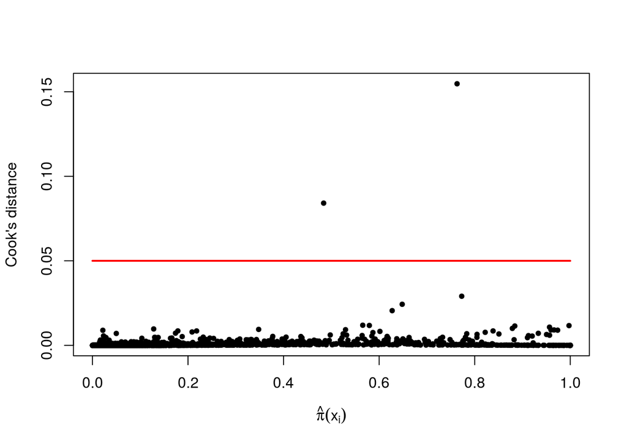

```
##
## Call:
## glm(formula = y ~ duration + campaign + emp.var.rate + cons.price.idx +
##     cons.conf.idx + poutcome + month + contact + month:duration +
##     duration:cons.price.idx + poutcome:month, family = binomial(),
##     data = data2)
##
## Deviance Residuals:
##     Min       1Q   Median       3Q      Max
## -3.3213  -0.2497  -0.1407  -0.0920   2.8843
##
## Coefficients:
##                                Estimate Std. Error z value Pr(>|z|)
## (Intercept)                  -1.451e+02  2.413e+01  -6.011 1.84e-09 ***
## duration                     -1.423e-02  5.520e-02  -0.258  0.79657
## campaign                     -1.159e-01  4.872e-02  -2.379  0.01736 *
## emp.var.rate                 -1.107e+00  9.114e-02 -12.147  < 2e-16 ***
## cons.price.idx                1.522e+00  2.629e-01   5.791 7.01e-09 ***
## cons.conf.idx                 5.928e-02  2.045e-02   2.899  0.00374 **
## poutcomenonexistent           1.296e+00  6.249e-01   2.074  0.03809 *
## poutcomesuccess               2.722e+00  1.116e+00   2.439  0.01473 *
## monthaug                      5.284e-01  9.015e-01   0.586  0.55780
## monthdec                      2.907e+00  1.225e+00   2.374  0.01761 *
## monthjul                     -6.266e-01  1.044e+00  -0.600  0.54844
## monthjun                      6.690e-01  9.941e-01   0.673  0.50093
## monthmar                      2.598e+00  1.094e+00   2.375  0.01756 *
## monthmay                     -3.604e-01  8.157e-01  -0.442  0.65863
## monthnov                      6.976e-01  8.686e-01   0.803  0.42188
## monthoct                      8.248e-01  1.009e+00   0.817  0.41367
## monthsep                      9.229e-01  1.075e+00   0.858  0.39072
## contacttelephone             -8.417e-01  2.662e-01  -3.162  0.00157 **
## duration:monthaug             2.521e-03  1.172e-03   2.150  0.03153 *
## duration:monthdec            -3.244e-03  2.140e-03  -1.516  0.12954
## duration:monthjul             2.118e-03  1.174e-03   1.804  0.07116 .
## duration:monthjun             2.081e-03  1.244e-03   1.672  0.09445 .
## duration:monthmar            -2.005e-03  1.956e-03  -1.025  0.30524
## duration:monthmay             1.982e-03  9.901e-04   2.002  0.04530 *
## duration:monthnov             9.320e-04  1.111e-03   0.839  0.40169
## duration:monthoct             1.779e-03  2.541e-03   0.700  0.48393
## duration:monthsep            -4.976e-04  2.376e-03  -0.209  0.83412
```

[output cut: 14 more lines]

```
## poutcomesuccess:monthnov     -1.357e+00  1.332e+00  -1.019  0.30817
## poutcomenonexistent:monthoct -1.273e+00  8.963e-01  -1.420  0.15551
## poutcomesuccess:monthoct     -2.064e+00  1.504e+00  -1.373  0.16982
## poutcomenonexistent:monthsep -9.761e-01  9.475e-01  -1.030  0.30295
## poutcomesuccess:monthsep     -4.417e-01  1.410e+00  -0.313  0.75406
## ---
## Signif. codes:  0 '***' 0.001 '**' 0.01 '*' 0.05 '.' 0.1 ' ' 1
##
## (Dispersion parameter for binomial family taken to be 1)
##
##     Null deviance: 2789.1  on 4091  degrees of freedom
## Residual deviance: 1471.3  on 4046  degrees of freedom
## AIC: 1563.3
##
## Number of Fisher Scoring iterations: 14
```

Сравним полученные коэффициенты с коэффициентами модели, настроенной по полным данным:

```
##                                   All data Filtered data
## (Intercept)                  -1.325243e+02 -1.450794e+02
## duration                     -7.207449e-02 -1.423028e-02
## campaign                     -1.118801e-01 -1.159145e-01
## emp.var.rate                 -1.127322e+00 -1.107090e+00
## cons.price.idx                1.381091e+00  1.522370e+00
## cons.conf.idx                 4.705042e-02  5.927880e-02
## poutcomenonexistent           1.288718e+00  1.295951e+00
## poutcomesuccess               2.774166e+00  2.721834e+00
## monthaug                      6.618151e-01  5.283880e-01
## monthdec                      2.969968e+00  2.906558e+00
## monthjul                     -4.163784e-01 -6.265570e-01
## monthjun                      9.038303e-01  6.690360e-01
## monthmar                      2.674419e+00  2.598083e+00
## monthmay                     -2.492515e-01 -3.603831e-01
## monthnov                      7.965961e-01  6.976215e-01
## monthoct                      1.764047e+00  8.248143e-01
## monthsep                      1.707465e+00  9.229215e-01
## contacttelephone             -8.756661e-01 -8.417291e-01
## duration:monthaug             2.419122e-03  2.521079e-03
## duration:monthdec            -2.986137e-03 -3.244149e-03
## duration:monthjul             1.619354e-03  2.117907e-03
## duration:monthjun             1.462200e-03  2.080814e-03
## duration:monthmar            -1.943693e-03 -2.005186e-03
## duration:monthmay             1.802560e-03  1.981980e-03
## duration:monthnov             8.788680e-04  9.319777e-04
## duration:monthoct            -2.532617e-03  1.778744e-03
## duration:monthsep            -3.263545e-03 -4.976246e-04
## duration:cons.price.idx       8.209848e-04  1.997819e-04
## poutcomenonexistent:monthaug -7.628852e-01 -8.090588e-01
## poutcomesuccess:monthaug     -1.028170e+00 -9.645510e-01
## poutcomenonexistent:monthdec -1.150057e+00 -1.167851e+00
## poutcomesuccess:monthdec     -2.828927e+00 -2.783666e+00
## poutcomenonexistent:monthjul  1.728039e-01  1.643222e-01
## poutcomesuccess:monthjul     -2.375345e+00 -2.274135e+00
## poutcomenonexistent:monthjun -1.148911e+00 -1.124867e+00
## poutcomesuccess:monthjun     -1.438559e+00 -1.331000e+00
## poutcomenonexistent:monthmar  1.683772e-01  2.686239e-01
## poutcomesuccess:monthmar      1.308732e+01  1.314785e+01
## poutcomenonexistent:monthmay -1.099717e+00 -1.085987e+00
## poutcomesuccess:monthmay     -1.081049e-01 -2.626370e-02
## poutcomenonexistent:monthnov -1.790638e+00 -1.776822e+00
## poutcomesuccess:monthnov     -1.430031e+00 -1.356953e+00
## poutcomenonexistent:monthoct -1.240083e+00 -1.273098e+00
## poutcomesuccess:monthoct     -1.866015e+00 -2.063975e+00
## poutcomenonexistent:monthsep -1.008875e+00 -9.760842e-01
## poutcomesuccess:monthsep     -4.250243e-01 -4.416561e-01
```

Различия большие по некоторым коэффициентам, возьмём модель 8.

[figure not shown]

```r
m0 <- glm(y~1, family=binomial(), data=data2)
```